# ANLYTC3 Finals Project

3. Impact of Class Size on Language Test Scores: This explores the relationship between class size and language test scores.

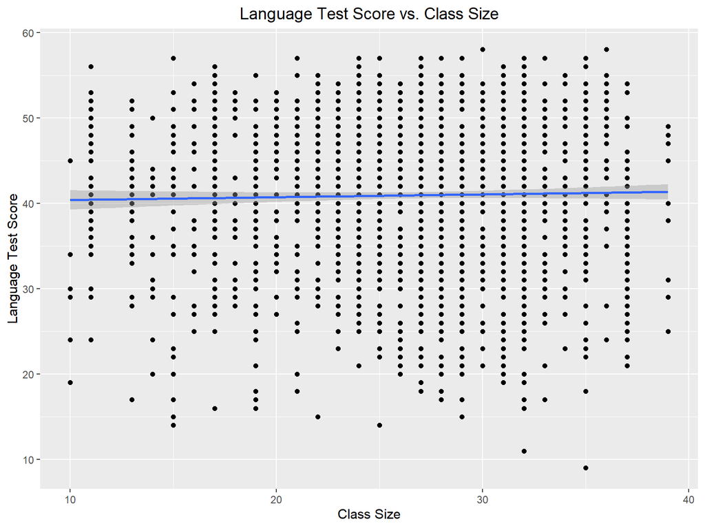

```r
# Create a scatter plot to visualize the relationship between class size and language test scores
ggplot(data = nlschools, mapping = aes(x = GS, y = lang)) +
  geom_point() +
  # Add a linear regression line
  geom_smooth(method = 'lm') +
  labs(x = 'Class Size', y = 'Language Test Score',
       title = 'Language Test Score vs. Class Size') +
  theme(plot.title = element_text(hjust = 0.5))
```

The line remains relatively flat, indicating that the average test score does not significantly change with class size. Class size alone does not appear to strongly influence test performance.

4. IQ vs Language Test Score: This assesses the correlation between students’ IQ and their language test scores.

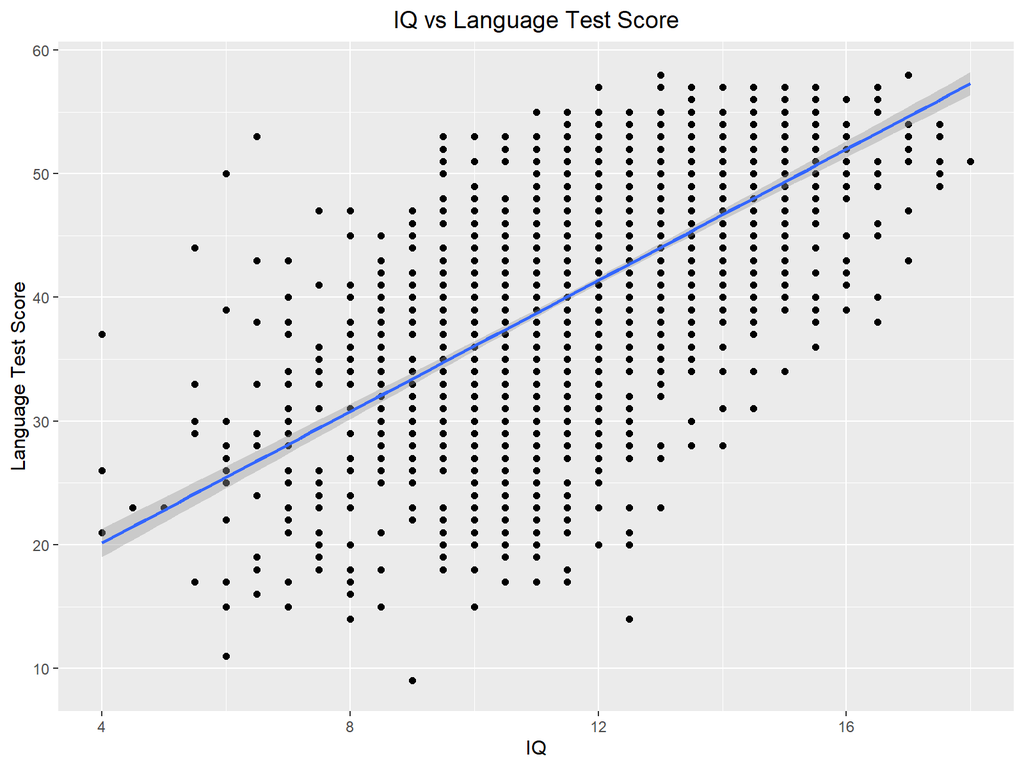

```r
# Create a scatter plot to visualize the relationship between IQ and language test scores
ggplot(data = nlschools, mapping = aes(x = IQ, y = lang)) +
  geom_point() +
  geom_smooth(method = 'lm') +
  labs(x = 'IQ', y = 'Language Test Score',
       title = 'IQ vs Language Test Score') +
  theme(plot.title = element_text(hjust = 0.5))
```

The line represents a positive correlation between IQ and language test scores. As IQ increases, the language test score tends to increase as well. Students with higher IQ scores tend to perform better on language tests.

*Overall, students generally perform better on the language exam when their socio-economic status (SES) is higher and when their IQ is higher. Higher SES often correlates with access to resources such as quality education, books, and extracurricular activities, which can enhance language skills and cognitive development. Furthermore, higher IQ levels may indicate stronger cognitive abilities, including language processing, comprehension, and problem-solving skills, all of which are essential for success in language exams.*